# LOCAETA report: CO Landfills scenarios

Author: Yunha Lee (yunha.lee@carbonsolutionsllc.com)

Date: June 11, 2025

# Introduction

The primary objectives of this study are to assess the socioeconomic and air quality impacts of the landfill emission scenarios from CDPHE, which includes total 5 landfill facilities over CO.

# Emission Changes by Key Pollutants

Figure 1 summarizes the total emissions change by pollutants at each landfill facility (EIS_ID), resulting from the two landfill emission scenarios from CDPHE.

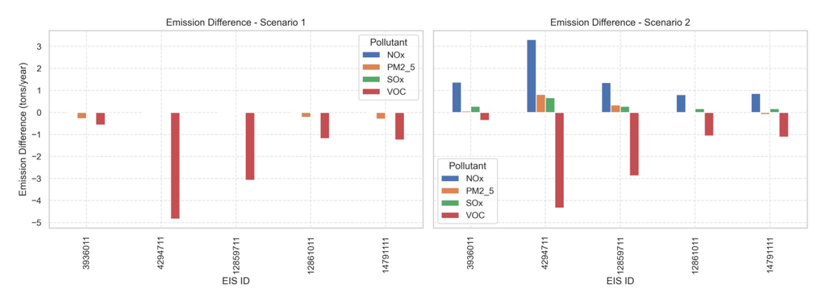

Figure 1: Change of air quality emissions at landfill facilities in CO

# Modeling Approaches

To evaluate the impacts on air quality and public health, we employed two well-established models: INMAP (Intervention Model for Air Pollution) and BenMAP (environmental BENefits Mapping and Analysis Program). InMAP is a reduced-complexity, Eulerian air quality model that estimates estimates annual-average concentrations of PM2.5 by simulating both primary and secondary PM formation. It is designed for emissions-to-health assessments and operates on a variable-resolution grid (~1 km in urban areas). Table 1 outlines the InMAP simulation configurations used in this study.

Table 1: Description of INMAP simulations used in this study

| INMAP run name | Description of Emissions |
| --- | --- |
| Base | 2020 NEI emissions |
| CO Landfills Scenario1 | 2020 NEI emissions with emission changes from "CO landfills_scenario1_no copollutants" |
| CO Landfills Scenario2 | 2020 NEI emissions with emission changes from "CO landfills_scenario2_co-pollutants" |

BenMAP is used to estimate the health outcomes and their monetized impacts attributable to changes in PM2.5 exposure. We considered six health endpoints and stratified the results by race and ethnicity when possible: - Asthma exacerbation: cough, wheezing, and shortness of breath - Workday loss - All-cause mortality (two methods used: **Method 1**: Di et al. and **Method 2**: Pope et al.)

Table 2 summarizes the health endpoints and valuation methods used in our BenMAP analysis. It used the InMAP outputs that are spatially aggregated to the county level to match BenMAP’s resolution requirements.

Table 2: Description of BenMAP health endpoints and valuation used in this study

Health endpoint

Race-ethnic stratified

Reference

Valuation method

Asthma exacerbation

- Cough
- Wheezing
- Shortness of Breath

All, Black

Ostro et al. (2001)  
Age: 8–13

WTP (Willingness to Pay): 1 symptom-day,  
Dickie and Ulery (2002)  
LogNormal | 0–17

Mortality

All, Black, White, Asian,  
Hispanic, and NatAmer

**Method 1**: Di et al. (2017)  
Age: over 64

VSL (Value of Statistical Life), based on 26 value-of-life studies, with Cessation Lag, 3% d.r.  
Weibull | 0–99

**Method 2**: Pope et al. (2019)  
Age: over 30

Workday loss

All

Ostro (1987)  
Age: 18–64

Median daily wage, county-specific  
None | 18–65

# Air Quality Impacts

Figure 2 presents the area-weighted average concentrations of various air pollutant species across different runs: all the values shown in this figures are also presented in Table 3. The vertical axis represents concentration changes in micrograms per cubic meter (μg/m³), with positive values indicating increases and negative values indicating decreases in pollutant concentrations. The horizontal axis displays nine air quality species: NH3 (ammonia), SOA (secondary organic aerosols), NOx (nitrogen oxides), SOx (sulfur oxides), PNH4 (particulate ammonium), PNO3 (particulate nitrate), PSO4 (particulate sulfate), PrimPM25 (primary PM2.5), and TotalPM25 (total PM2.5). It shows how each run scenario affects the atmospheric composition of different pollutants. The concentration changes, in terms of trend and mangnitude, align closely with the emission reductions.

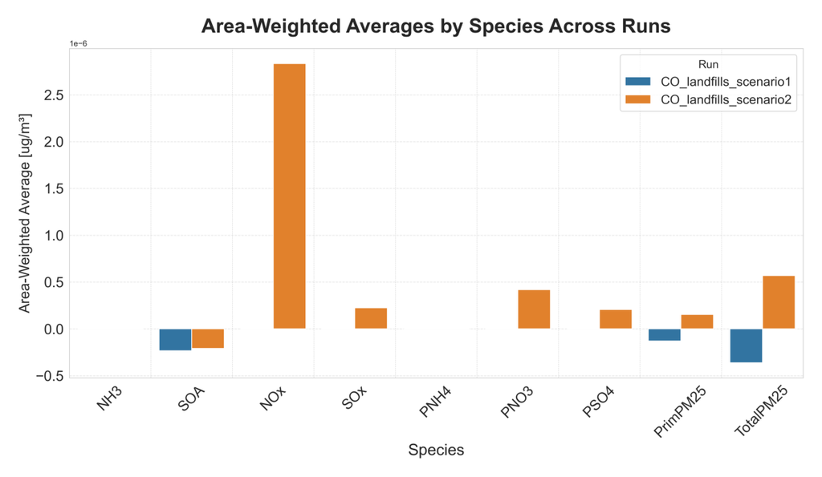

Figure 2: Change of area-weighted average of air quality species for all runs

Table 3: Change of area-weighted average of air quality species from all runs

| Species | CO_landfills_scenario1 | CO_landfills_scenario2 |
| --- | --- | --- |
| NH3 | 6.5573e-17 | 6.5573e-17 |
| NOx | -3.8706e-18 | 2.8343e-06 |
| PNH4 | 2.8368e-17 | 2.8368e-17 |
| PNO3 | 5.6736e-17 | 4.1857e-07 |
| PSO4 | 1.6459e-18 | 2.057e-07 |
| PrimPM25 | -1.2969e-07 | 1.5302e-07 |
| SOA | -2.3325e-07 | -2.0887e-07 |
| SOx | 1.6523e-17 | 2.2507e-07 |
| TotalPM25 | -3.6295e-07 | 5.6842e-07 |

Subsequent analysis focuses on total PM2.5 concentrations, which are the primary driver of health impacts. Figure 3 presents spatial maps showing the percent changes in total PM2.5 concentrations across all runs. The color scale ranges from blue (representing decreases in PM2.5) to red (representing increases), with intensity indicating the magnitude of change.

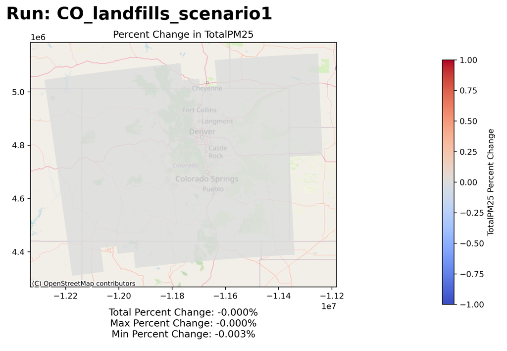

(a)

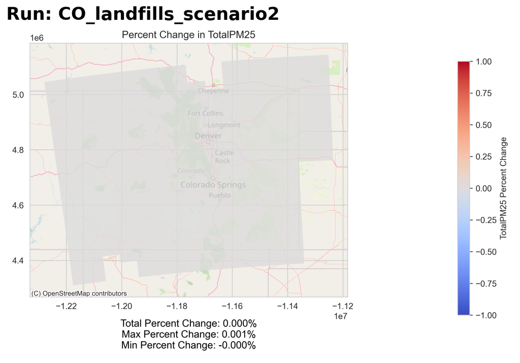

(b)

Figure 3: Spatial distribution of percent changes in total PM₂.5 concentrations across all runs

# Public Health Impacts

Comprehensive analysis of health impacts across runs are provided in this section, with results stratified by race-ethnicity and measured through the various health endpoints. Our goal is to collectively provide a multidimensional view of how various run scenarios affect public health outcomes across different demographic groups, measured both in health terms and economic value.

Figure 4 illustrates the absolute health benefits across runs for six key health endpoints: asthma exacerbation (cough, shortness of breath, and wheeze), mortality (calculated using two different methodologies by Di et al. and Pope et al.), and work loss days. The data is stratified primarily by race-ethnicity categories (ALL, BLACK, ASIAN, HISPANIC, NATAMER, and WHITE). The vertical axis represents health benefits, with positive values indicating improvements and negative values indicating negative impacts. Different runs are represented by different colored bars. All the values used in this figure can be found in Table 4.

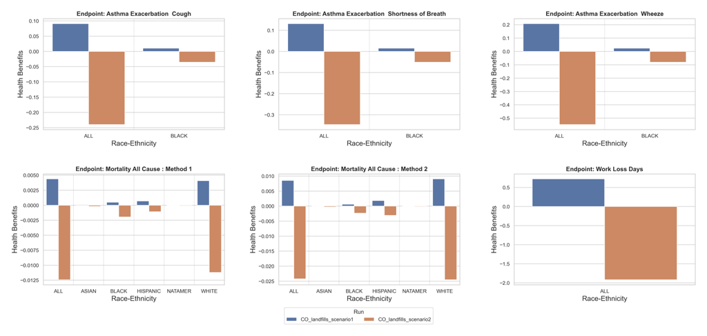

Figure 4: Impact on health benefits across all runs

Table 4: Values of health benefits from all runs

| Endpoint | Race | CO_landfills_scenario1 | CO_landfills_scenario2 |
| --- | --- | --- | --- |
| Asthma Exacerbation Cough | ALL | 0.0909 | -0.2397 |
| Asthma Exacerbation Cough | BLACK | 0.01054 | -0.03549 |
| Asthma Exacerbation Shortness of Breath | ALL | 0.1312 | -0.3458 |
| Asthma Exacerbation Shortness of Breath | BLACK | 0.01521 | -0.05121 |
| Asthma Exacerbation Wheeze | ALL | 0.2076 | -0.5473 |
| Asthma Exacerbation Wheeze | BLACK | 0.02407 | -0.08105 |
| Mortality All Cause : Method 1 | ALL | 0.004383 | -0.01242 |
| Mortality All Cause : Method 1 | ASIAN | 7.712e-05 | -0.0001922 |
| Mortality All Cause : Method 1 | BLACK | 0.0004963 | -0.001952 |
| Mortality All Cause : Method 1 | HISPANIC | 0.0006951 | -0.001083 |
| Mortality All Cause : Method 1 | NATAMER | 6.015e-05 | -9.526e-05 |
| Mortality All Cause : Method 1 | WHITE | 0.004097 | -0.01121 |
| Mortality All Cause : Method 2 | ALL | 0.00854 | -0.02423 |
| Mortality All Cause : Method 2 | ASIAN | 0.000107 | -0.0002714 |
| Mortality All Cause : Method 2 | BLACK | 0.0006028 | -0.002329 |
| Mortality All Cause : Method 2 | HISPANIC | 0.001859 | -0.003085 |
| Mortality All Cause : Method 2 | NATAMER | 0.0001119 | -0.0001795 |
| Mortality All Cause : Method 2 | WHITE | 0.009048 | -0.02453 |
| Work Loss Days | ALL | 0.7222 | -1.919 |

Figure 5 presents the same health endpoints as Figure 4 but normalizes the benefits by population size (per million people): : all the values used in this figure can be found in Table 5. This normalization allows for more equitable comparison across demographic groups of different sizes. The health endpoints and runs remain consistent with Figure 4. The normalization reveals per capita impacts, highlighting potential disparities in health benefits that might be obscured in absolute numbers.

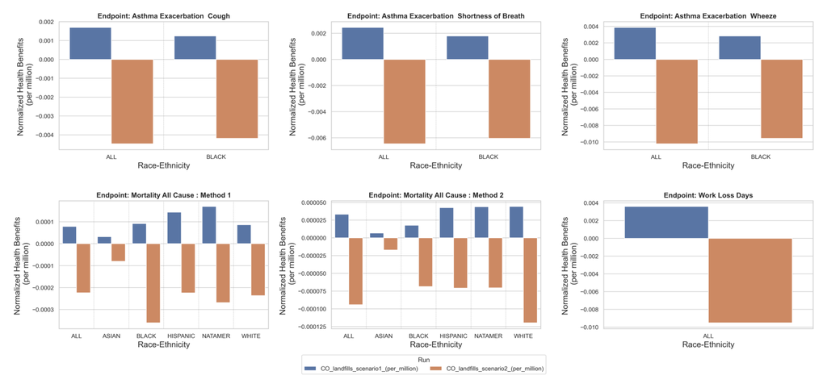

Figure 5: Impact on health benefits normalized by the population (in miilion) across all runs

Table 5: Values of normalized health benefits from all runs

| Endpoint | Race | CO_landfills_scenario1_(per_million) | CO_landfills_scenario2_(per_million) |
| --- | --- | --- | --- |
| Asthma Exacerbation Cough | ALL | 0.001697 | -0.004474 |
| Asthma Exacerbation Cough | BLACK | 0.001243 | -0.004187 |
| Asthma Exacerbation Shortness of Breath | ALL | 0.002448 | -0.006456 |
| Asthma Exacerbation Shortness of Breath | BLACK | 0.001794 | -0.006041 |
| Asthma Exacerbation Wheeze | ALL | 0.003875 | -0.01022 |
| Asthma Exacerbation Wheeze | BLACK | 0.002839 | -0.009561 |
| Mortality All Cause : Method 1 | ALL | 7.895e-05 | -0.0002237 |
| Mortality All Cause : Method 1 | ASIAN | 3.207e-05 | -7.99e-05 |
| Mortality All Cause : Method 1 | BLACK | 9.169e-05 | -0.0003606 |
| Mortality All Cause : Method 1 | HISPANIC | 0.0001439 | -0.0002242 |
| Mortality All Cause : Method 1 | NATAMER | 0.0001695 | -0.0002684 |
| Mortality All Cause : Method 1 | WHITE | 8.652e-05 | -0.0002367 |
| Mortality All Cause : Method 2 | ALL | 3.321e-05 | -9.421e-05 |
| Mortality All Cause : Method 2 | ASIAN | 6.739e-06 | -1.709e-05 |
| Mortality All Cause : Method 2 | BLACK | 1.776e-05 | -6.863e-05 |
| Mortality All Cause : Method 2 | HISPANIC | 4.267e-05 | -7.082e-05 |
| Mortality All Cause : Method 2 | NATAMER | 4.392e-05 | -7.044e-05 |
| Mortality All Cause : Method 2 | WHITE | 4.418e-05 | -0.0001198 |
| Work Loss Days | ALL | 0.003581 | -0.009515 |

Figure 6 displays only the premature mortality results for all race-ethnicity groups from Figure 4, as mortality represents the most significant health impacts. The figure shows the annual number of avoided premature deaths and compares estimates computed using the two different mortality risk functions (Di et al. vs Pope et al.).

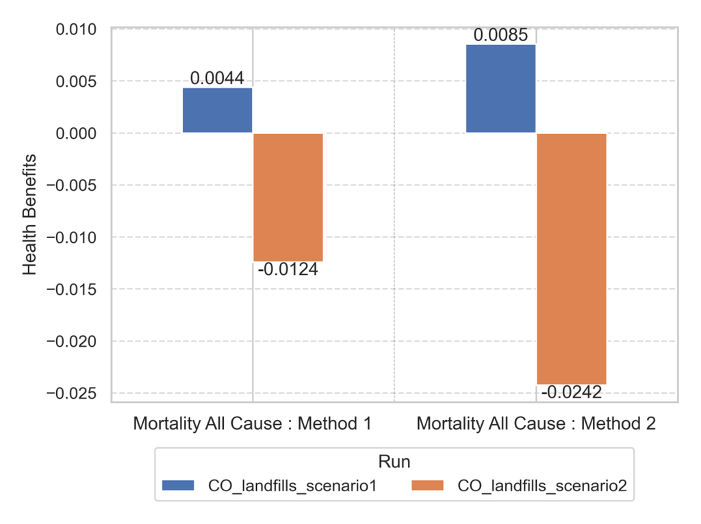

Figure 6: Annual number of avoided premature deaths across all runs

Figure 7 translates the health impacts into monetary values (in million dollars), providing an economic perspective on the health benefits of each run. The vertical axis shows monetized health benefits per million dollars, maintaining the same stratification by race-ethnicity and health endpoints as the previous figures: all the values used in this figure can be found in Table 6. Mortality is the primary contributor to the total menetary values. The two mortality estimate approaches (Di et al. vs Pope et al.) yield noticeably different results, which is also reflected in their respective health benefits estimates. This economic quantification enables cost-benefit analysis of the different run scenarios and highlights which interventions may provide the greatest economic return through health improvements.

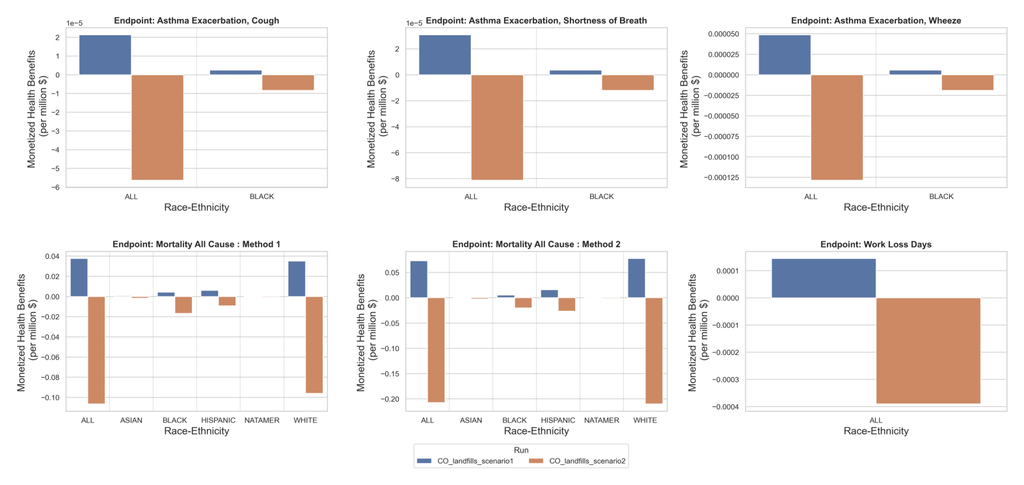

Figure 7: Monetized health benefits (in miilion dollars) across all runs

Table 6: Values of monetized health benefits from all runs

| Endpoint | Race | CO_landfills_scenario1 | CO_landfills_scenario2 |
| --- | --- | --- | --- |
| Asthma Exacerbation, Cough | ALL | 2.133e-05 | -5.625e-05 |
| Asthma Exacerbation, Cough | BLACK | 2.473e-06 | -8.329e-06 |
| Asthma Exacerbation, Shortness of Breath | ALL | 3.078e-05 | -8.116e-05 |
| Asthma Exacerbation, Shortness of Breath | BLACK | 3.569e-06 | -1.202e-05 |
| Asthma Exacerbation, Wheeze | ALL | 4.871e-05 | -0.0001284 |
| Asthma Exacerbation, Wheeze | BLACK | 5.648e-06 | -1.902e-05 |
| Mortality All Cause : Method 1 | ALL | 0.03755 | -0.1064 |
| Mortality All Cause : Method 1 | ASIAN | 0.0006604 | -0.001646 |
| Mortality All Cause : Method 1 | BLACK | 0.004251 | -0.01672 |
| Mortality All Cause : Method 1 | HISPANIC | 0.005951 | -0.00927 |
| Mortality All Cause : Method 1 | NATAMER | 0.0005146 | -0.000815 |
| Mortality All Cause : Method 1 | WHITE | 0.03509 | -0.096 |
| Mortality All Cause : Method 2 | ALL | 0.0731 | -0.2074 |
| Mortality All Cause : Method 2 | ASIAN | 0.0009142 | -0.002319 |
| Mortality All Cause : Method 2 | BLACK | 0.005155 | -0.01992 |
| Mortality All Cause : Method 2 | HISPANIC | 0.0159 | -0.02639 |
| Mortality All Cause : Method 2 | NATAMER | 0.0009562 | -0.001534 |
| Mortality All Cause : Method 2 | WHITE | 0.07742 | -0.2099 |
| Work Loss Days | ALL | 0.0001447 | -0.0003899 |

Because the total monetary value of health benefits is largely driven by reduction in mortality, we present the monetized health benefit by mortality separately in Figure 8. As shown in Figure 6, the choice of mortality risk functions - Di et al. vs Pope et al. - results in a signnificant difference in the estimated total monetaried benefits.

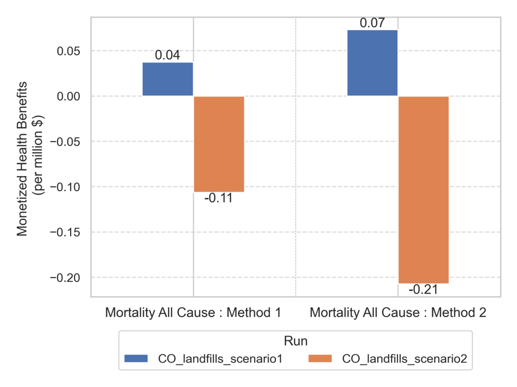

Figure 8: Monetized health benefits by mortality (in miilion dollars) for all runs